# Predicting Bikeshare Demand

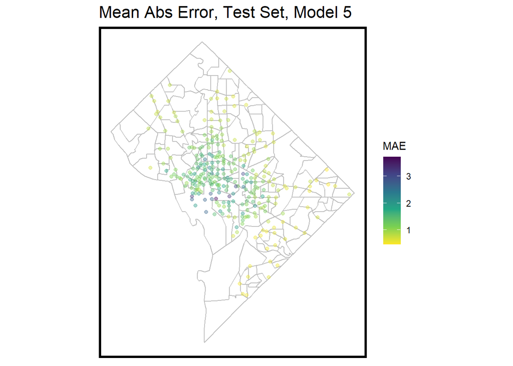

```r
week_predictions %>%
    mutate(interval60 = map(data, pull, interval60),
           start_station_id = map(data, pull, start_station_id),
           start_lat = map(data, pull, start_lat),
           start_lng = map(data, pull, start_lng),
           start_station_name = map(data,pull,start_station_name)) %>%
    select(interval60, start_station_id, start_lng, start_lat, start_station_name, Observed, Prediction, Regression) %>%
    unnest() %>%
  left_join(., docks, by =c("start_station_name" = "NAME")) %>%
  st_sf() %>%
  filter(Regression == "DTime_Space_FE_timeLags") %>%
  group_by(start_station_id, start_lng, start_lat) %>%
  summarize(MAE = mean(abs(Observed-Prediction), na.rm = TRUE)) %>%
ggplot(.)+
  geom_sf(data = tractsDC, color = "grey", fill = "transparent") +
  geom_sf(aes(color = MAE), fill = "transparent", alpha = 0.4) +
  scale_colour_viridis_c(direction = -1, option = "D")+
  # ylim(min(dat_census$start_lat), max(dat_census$start_lat))+
  # xlim(min(dat_census$start_lng), max(dat_census$start_lng))+
  labs(title="Mean Abs Error, Test Set, Model 5")+
  mapTheme()
```

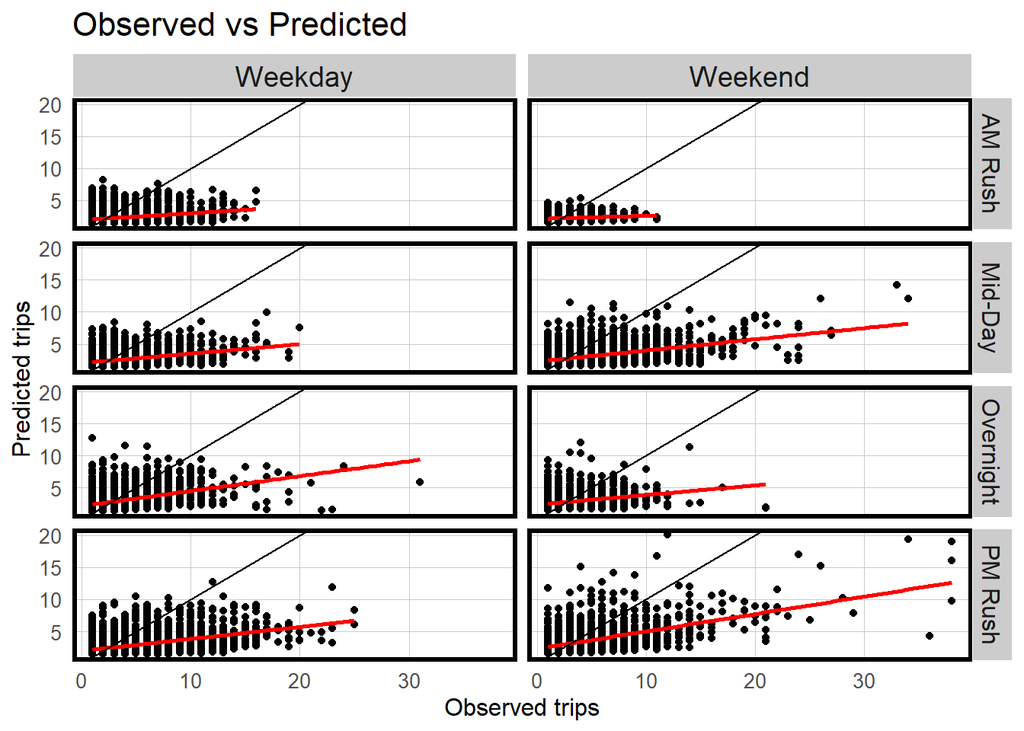

```r
week_predictions %>%
    mutate(interval60 = map(data, pull, interval60),
           start_station_id = map(data, pull, start_station_id),
           start_lat = map(data, pull, start_lat),
           start_lng = map(data, pull, start_lng),
           dotw = map(data, pull, dotw)) %>%
    select(interval60, start_station_id, start_lng,
           start_lng, Observed, Prediction, Regression,
           dotw) %>%
    unnest() %>%
  filter(Regression == "DTime_Space_FE_timeLags")%>%
  mutate(weekend = ifelse(dotw %in% c("Sun", "Sat"), "Weekend", "Weekday"),
         time_of_day = case_when(hour(interval60) < 7 | hour(interval60) > 18 ~ "Overnight",
                                 hour(interval60) >= 7 & hour(interval60) < 10 ~ "AM Rush",
                                 hour(interval60) >= 10 & hour(interval60) < 15 ~ "Mid-Day",
                                 hour(interval60) >= 15 & hour(interval60) <= 18 ~ "PM Rush"))%>%
  ggplot()+
  geom_point(aes(x= Observed, y = Prediction))+
    geom_smooth(aes(x= Observed, y= Prediction), method = "lm", se = FALSE, color = "red")+
    geom_abline(slope = 1, intercept = 0)+
  facet_grid(time_of_day~weekend)+
  labs(title="Observed vs Predicted",
       x="Observed trips",
       y="Predicted trips")+
  plotTheme()
```

# 5. Cross Validation

```r
ride.crossVal <- ride.Test %>% filter(week %in% c(42,44)) %>%
  left_join(., docks, by =c("start_station_name" = "NAME")) %>%
  st_sf()

fitControl <- trainControl(method = "cv",
                                   number = 50)
set.seed(717)

reg4.cv <-
  train (Trip_Count ~  start_station_id +  hour(interval60) + dotw + Temperature + Precipitation + Wind_Speed +lagHour + lag2Hours + lag3Hours, data=ride.crossVal,
               method = "lm",
               trControl = fitControl,
               na.action = na.pass)
reg4.cv
```

```
## Linear Regression
##
## 25866 samples
##    10 predictor
##
## No pre-processing
## Resampling: Cross-Validated (50 fold)
## Summary of sample sizes: 25348, 25349, 25348, 25347, 25348, 25348, ...
## Resampling results:
##
##   RMSE      Rsquared   MAE
##   2.103998  0.1616397  1.440104
##
## Tuning parameter 'intercept' was held constant at a value of TRUE
```

```r
kable(reg4.cv$resample) %>%
  kable_styling(font_size = 12, full_width = F,
                bootstrap_options = c("striped", "hover", "condensed")) %>%
  footnote(general = "Table 5.3 Cross-validation Test on Model D",
           general_title= '\n') %>%
  scroll_box(width = "100%", height = "200px")
```

| RMSE | Rsquared | MAE | Resample |
| --- | --- | --- | --- |
| 2.473754 | 0.1422125 | 1.475307 | Fold01 |
| 2.167165 | 0.0826523 | 1.465781 | Fold02 |
| 1.987142 | 0.1689085 | 1.398805 | Fold03 |
| 1.957100 | 0.1767832 | 1.372911 | Fold04 |
| 1.945097 | 0.1458917 | 1.393949 | Fold05 |
| 2.263134 | 0.2221541 | 1.490716 | Fold06 |
| 1.845732 | 0.1908464 | 1.362475 | Fold07 |
| 1.830896 | 0.1361980 | 1.328071 | Fold08 |
| 2.048525 | 0.0707696 | 1.448735 | Fold09 |
| 2.164203 | 0.1324850 | 1.485445 | Fold10 |
| 2.306694 | 0.2110264 | 1.493123 | Fold11 |
| 2.308239 | 0.1590646 | 1.514799 | Fold12 |
| 2.186101 | 0.2965863 | 1.432215 | Fold13 |
| 2.307045 | 0.2162193 | 1.467102 | Fold14 |
| 2.251803 | 0.1269661 | 1.494683 | Fold15 |
| 2.339575 | 0.1547617 | 1.556021 | Fold16 |
| 2.548763 | 0.1272819 | 1.522421 | Fold17 |
| 2.186997 | 0.2050269 | 1.485635 | Fold18 |
| 1.924093 | 0.1515834 | 1.383575 | Fold19 |
| 1.959918 | 0.2051074 | 1.381013 | Fold20 |
| 2.171906 | 0.0803278 | 1.457955 | Fold21 |
| 2.141680 | 0.0662987 | 1.510941 | Fold22 |
| 1.838610 | 0.1830580 | 1.325892 | Fold23 |
| 2.190356 | 0.1778699 | 1.482814 | Fold24 |
| 1.856745 | 0.1985419 | 1.384441 | Fold25 |
| 2.132708 | 0.1873257 | 1.428748 | Fold26 |
| 2.337865 | 0.2787127 | 1.478365 | Fold27 |
| 1.828545 | 0.1310881 | 1.309397 | Fold28 |
| 2.243816 | 0.1414644 | 1.489276 | Fold29 |
| 2.136657 | 0.1881131 | 1.468684 | Fold30 |
| 2.083942 | 0.2122822 | 1.464857 | Fold31 |
| 1.930396 | 0.0773577 | 1.405716 | Fold32 |
| 1.744033 | 0.2106118 | 1.278056 | Fold33 |
| 2.201500 | 0.1799389 | 1.496625 | Fold34 |
| 2.243170 | 0.1034242 | 1.543924 | Fold35 |
| 2.003258 | 0.1583053 | 1.441740 | Fold36 |
| 1.750792 | 0.1061937 | 1.312761 | Fold37 |
| 2.074950 | 0.1470001 | 1.422201 | Fold38 |
| 2.155158 | 0.1287428 | 1.423301 | Fold39 |
| 2.260596 | 0.2074432 | 1.494264 | Fold40 |
| 2.044670 | 0.2367811 | 1.374785 | Fold41 |
| 1.922001 | 0.1672501 | 1.373024 | Fold42 |
| 2.016203 | 0.1403309 | 1.429682 | Fold43 |
| 2.085763 | 0.1952771 | 1.435169 | Fold44 |
| 1.989632 | 0.1665937 | 1.418669 | Fold45 |
| 2.388555 | 0.1651726 | 1.525521 | Fold46 |
| 2.092547 | 0.0890350 | 1.517092 | Fold47 |
| 1.984484 | 0.0845938 | 1.413231 | Fold48 |
| 2.159406 | 0.1679132 | 1.528448 | Fold49 |
| 2.188000 | 0.1824129 | 1.416821 | Fold50 |

Table 5.3 Cross-validation Test on Model D

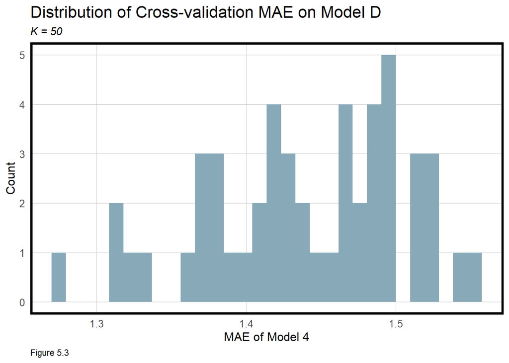

```r
ggplot(data = reg4.cv$resample) +
  geom_histogram(aes(x = reg4.cv$resample$MAE), fill = '#88aab8') +
  labs(title="Distribution of Cross-validation MAE on Model D",
       subtitle = "K = 50",
       caption = "Figure 5.3 ") +
  xlab('MAE of Model 4') +
  ylab('Count') +
  plotTheme()
```

# 6. Conclusions

While, strong predictors of ridership, and thus the ability to re-balance bikes across the network, were identified, the models presented in this study still need further tuning. While results shown in the Predicted vs Observed bike share time series figure indicate that the models can predict ridership well, goodness-of-fit metrics yield a different story, with a high Mean Absolute Error (MAE) of 1.44 and high Root-Mean-Squared-Error (RMSE) of 2.1. Further studies could allow for better generalizability across socioeconomic and spatial contexts. There is clearly a spatial process at play with regards to stations in the core of the District.